# German Rental Advanced Analysis and predction Models Part 1: Feature Analysis and Engeneering

### firingype

```r
temp = data_raw$firingTypes

length(unique(temp))
```

```
[1] 120
```

```r
sum(is.na(temp))
```

```
[1] 47957
```

With 48k NA’s and 120 different categories I will discard this feature for now. Grouping up 120 categories is of course possible but a lot of work and imputating roughly 50k entries does not seem to appealing to me as well.

```r
data_raw = subset(data_raw, select=-c(firingTypes))
```

### haskitchen

```r
temp = data_raw$hasKitchen

unique(temp)
```

```
[1] FALSE  TRUE
```

```r
sum(is.na(temp))
```

```
[1] 0
```

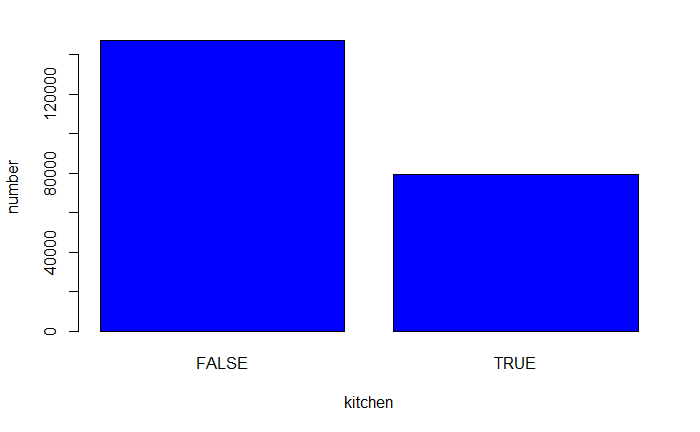

```r
plot(as.factor(temp), col="blue", xlab="kitchen", ylab="number")
```

```r
temp = ifelse(temp == FALSE, 0, 1)
```

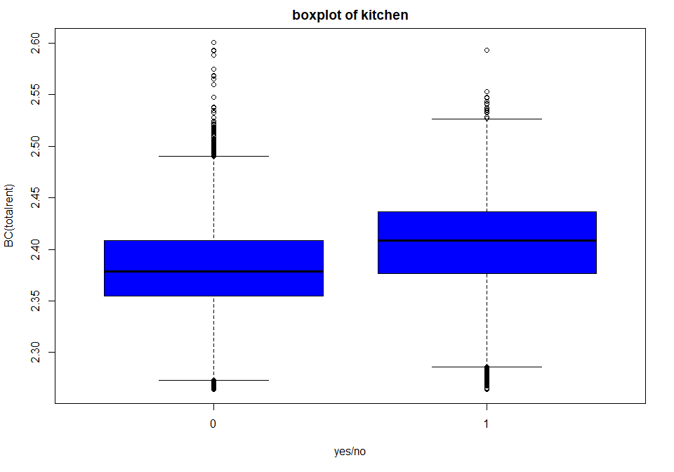

```r
boxplot(data_raw$totalRent~temp, col="blue", stroke="red",
        main="boxplot of kitchen", xlab = "yes/no", ylab="BC(totalrent)")
```

Flats with a kitchen are more expensive. This is not really suprising.

```r
data_raw$hasKitchen = temp
```

### geo_bln

```r
temp = data_raw$geo_bln
head(temp)
```

```
[1] "Sachsen"            "Niedersachsen"      "Schleswig_Holstein" "Baden_WÃ¼rttemberg" "Sachsen"            "Bayern"
```

This appears to be a duplicate of regio_1 so lets skip over it

```r
data_raw = subset(data_raw, select=-c(geo_bln))
```

### cellar

```r
temp = data_raw$cellar
unique(temp)
```

```
[1] FALSE  TRUE
```

```r
sum(is.na(temp))
```

```
[1] 0
```

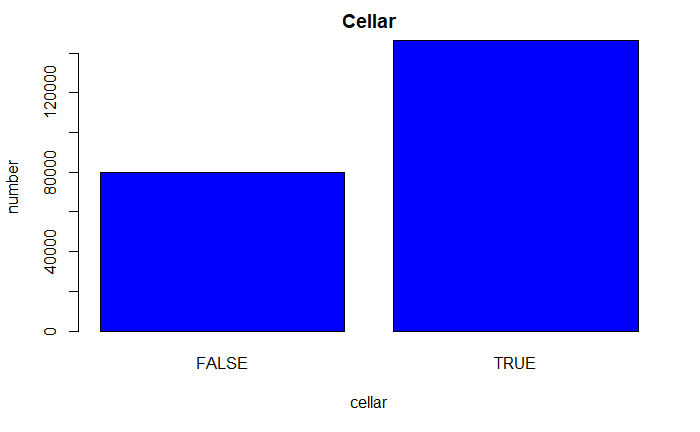

```r
plot(as.factor(temp), col="blue", xlab="cellar", ylab="number", main="Cellar")
```

So we do have more flats with a cellar. We would love to see these flats to be more expensive. But first we follow our usual encoding strategy.

```r
temp = ifelse(temp == FALSE, 0, 1)
```

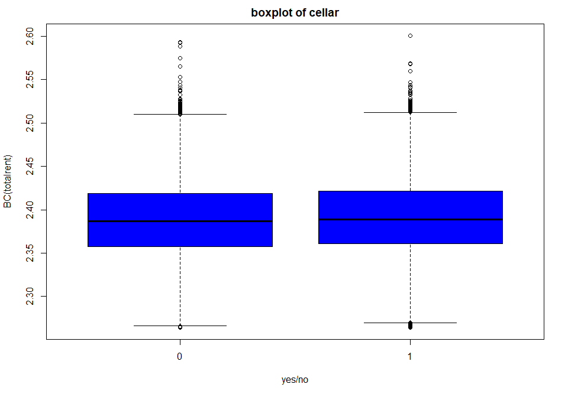

```r
boxplot(data_raw$totalRent~temp, col="blue", stroke="red",
        main="boxplot of cellar", xlab = "yes/no", ylab="BC(totalrent)")
```

This is odd. One would have expected a more drastic difference.

```r
data_raw$cellar = temp
```

### yearConstructedRange

```r
temp = data_raw$yearConstructedRange
head(temp, 20)
```

```
 [1]  1  8  3 NA NA  1  2  1  1  3  2  9  3  3  9  1  5  2 NA NA
```

```r
unique(temp)
```

```
 [1]  1  8  3 NA  2  9  5  4  6  7
```

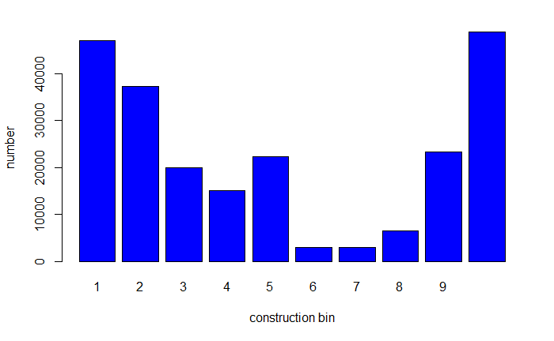

```r
plot(addNA(temp), col="blue", xlab="construction bin", ylab="number")
```

Since it is unclear how to interpret this feature we will leave this one out for now.

```r
data_raw = subset(data_raw, select=-c(yearConstructedRange))
```

### housenumber

```r
temp = data_raw$houseNumber
head(temp, 10)
```

```
 [1] NA   "3"  NA   NA   "66" NA   "14" NA   NA   "4"
```

```r
sum(is.na(temp))
```

```
[1] 53596
```

This column contains the housenumber of any given flat. This feature by itself is rather ambiguous and with 53k NA values I personally do not see any reason to keep it.

```r
data_raw = subset(data_raw, select=-c(houseNumber))
```

### livingspac

```r
temp = data_raw$livingSpace
length(unique(temp))
```

```
[1] 12466
```

```r
sum(is.na(temp))
```

```
[1] 0
```

This might be the single most important feature giving us the m^2 of the flat. Even better: we do not need to estimate any values since there are no NA’s

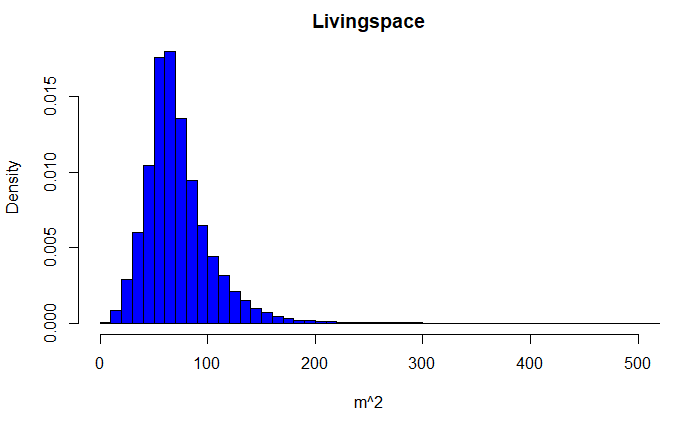

```r
hist(temp, col="blue", main="Livingspace", xlab="m^2", freq=FALSE, breaks=10000, xlim = c(0, 500))
```

The distribution looks nice but we apparently do have some extreme outliers!(can be seen if we remove the xlim)

```r
head(sort(temp, decreasing = TRUE), 10)
```

```
 [1] 111111.00  66100.00  10259.00   8684.00   4340.00   1000.00    649.00    601.85    600.00    566.00
```

Even tho there are some big flats having a living space of over 1000m^2 seems unrealistic for a FLAT. And since we are already looking at it lets see if we have some super low values aswell!

```r
head(sort(temp, decreasing = FALSE), 10)
```

```
 [1] 0 0 0 0 0 0 0 0 0 0
```

Disappointing! But so be it. Lets remove them.

```r
remove_ind = which(temp > 1000 | temp < 5)
length(remove_ind)
```

```
[1] 60
```

Only 60 thats not too bad.

```r
temp = temp[-remove_ind]
data_raw = data_raw[-remove_ind, ]
data_raw$livingSpace = temp
```

Lets see if we have a nice relationship between the target and the livingspace.

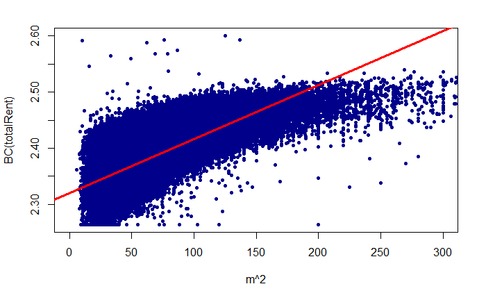

```r
plot(temp, data_raw$totalRent, xlab="m^2", ylab="BC(totalRent)", col="darkblue", pch=20, xlim=c(0, 300))
temp_model = lm(data_raw$totalRent~temp)
abline(temp_model, col="red", lwd=3)
```

```r
summary(temp_model)
```

```
Call:
lm(formula = data_raw$totalRent ~ temp)

Residuals:
     Min       1Q   Median       3Q      Max
-0.90961 -0.02001 -0.00188  0.01905  0.26295

Coefficients:
             Estimate Std. Error t value Pr(>|t|)
(Intercept) 2.320e+00  1.533e-04 15127.4   <2e-16 ***
temp        9.626e-04  1.931e-06   498.5   <2e-16 ***
---
Signif. codes:  0 ‘***’ 0.001 ‘**’ 0.01 ‘*’ 0.05 ‘.’ 0.1 ‘ ’ 1

Residual standard error: 0.02891 on 226266 degrees of freedom
Multiple R-squared:  0.5234,    Adjusted R-squared:  0.5234
F-statistic: 2.485e+05 on 1 and 226266 DF,  p-value: < 2.2e-16
```

```r
cor.test(temp, data_raw$totalRent)
```

```
    Pearson's product-moment correlation

data:  temp and data_raw$totalRent
t = 498.49, df = 226266, p-value < 2.2e-16
alternative hypothesis: true correlation is not equal to 0
95 percent confidence interval:
 0.7215003 0.7254278
sample estimates:
      cor
0.7234699
```

A positive correlation of 0.72! Thats what we want to see.

### geo_krs

```r
temp = data_raw$geo_krs
head(temp, 10)
```

```
 [1] "Mittelsachsen_Kreis" "GÃ¶ttingen_Kreis"    "NeumÃ¼nster"         "Stuttgart"           "Leipzig"             "MÃ¼nchen"            "Hamburg"             "Braunschweig"
 [9] "Esslingen_Kreis"     "Magdeburg"
```

```r
length(unique(data_raw$regio2))
```

```
[1] 419
```

```r
length(unique(temp))
```

```
[1] 419
```

This is another duplicate of the “regio” feature, in this case regio2.

```r
data_raw = subset(data_raw, select=-c(geo_krs))
```

### condition

```r
temp = data_raw$condition
head(temp, 10)
```

[output not shown]

So the condition gives us an impression of the state of the flat. Lets see how many categories we have.

```r
length(unique(temp))
sum(is.na(temp))
```

[output not shown]

11 Categories, thats good and with 56k NA’s we could just impute them as the average category.

```r
unique(temp)
```

```
 [1] "refurbished"                        "mint_condition"                     "well_kept"                          NA
 [5] "first_time_use_after_refurbishment" "fully_renovated"                    "first_time_use"                     "modernized"
 [9] "negotiable"                         "need_of_renovation"                 "ripe_for_demolition"
```

Lets convert them into a dummy variable and order the ordinals from worst to best.

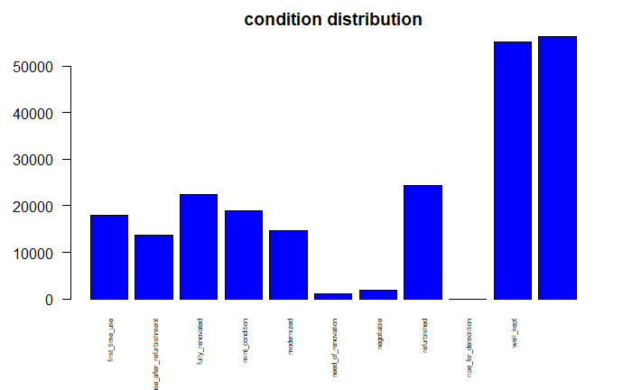

```r
plot(addNA(temp), col="blue", main="condition distribution", cex.names=0.5 ,las=2)
```

Most flats ware well kept so lets assume most flats we dont know the status of are also well kept.

```r
temp[is.na(temp)] = "well_kept"
con_levels = c("ripe_for_demolition","need_of_renovation", "negotiable",
               "refurbished","modernized","first_time_use_after_refurbishment",
               "fully_renovated", "well_kept", "mint_condition",
               "first_time_use")
temp = factor(temp, ordered = TRUE, levels=con_levels)
temp = as.numeric(temp)
```

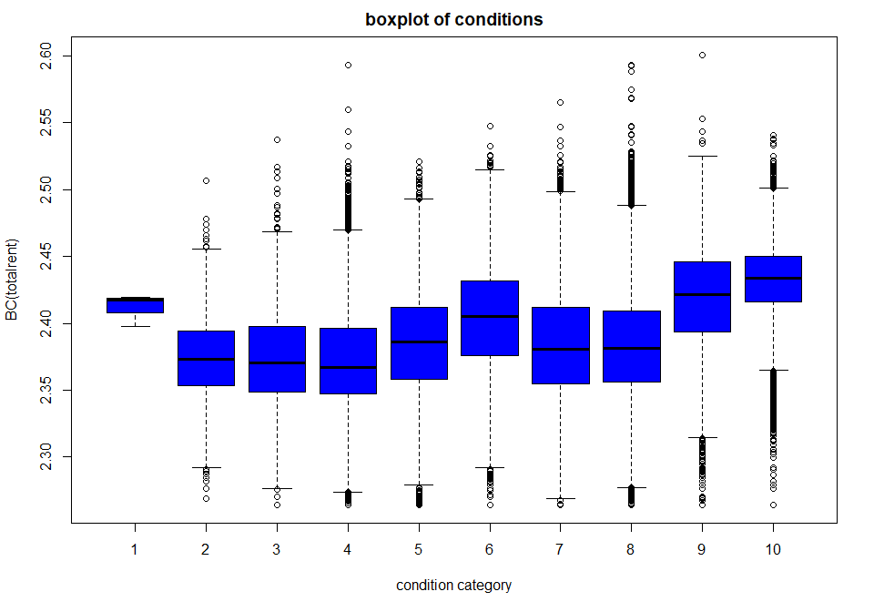

```r
boxplot(data_raw$totalRent~temp, col="blue", stroke="red",
        main="boxplot of conditions", xlab = "condition category", ylab="BC(totalrent)")
```

```r
data_raw$condition = temp
```

### interiorqual

```r
temp = data_raw$interiorQual
head(temp, 10)
```

```
 [1] "normal"        "sophisticated" "sophisticated" NA              NA              NA              "normal"        NA              NA              NA
```

The interiorqual is a categorical ordinal variable which gives information about the furnishing.

```r
length(unique(temp))
```

```
[1] 5
```

```r
sum(is.na(temp))
```

```
[1] 88060
```

```r
unique(temp)
```

```
[1] "normal"        "sophisticated" NA              "simple"        "luxury"
```

We apparently have 4 categories simple normal sophisticated and luxury. with 88k NA’s.

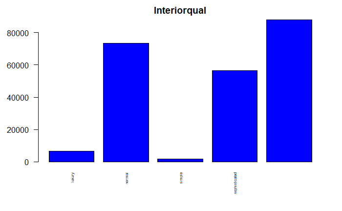

```r
plot(addNA(temp), col="blue", main="Interiorqual", cex.names=0.5 ,las=2)
```

This is surprising we have almost as many sophisticated flats as there are normal flats. Since there is no clear cut category where we can just dump the NA’s in and averaging is not an option either I will draw for these NA’s at random from the distribution given.

```r
cat_probs = c(length(temp[temp=='normal'& !is.na(temp)]) / (length(temp) - sum(is.na(temp))),
              length(temp[temp=='sophisticated'& !is.na(temp)]) / (length(temp) - sum(is.na(temp))),
              length(temp[temp=='simple'& !is.na(temp)]) / (length(temp) - sum(is.na(temp))),
              length(temp[temp=='luxury' & !is.na(temp)]) / (length(temp) - sum(is.na(temp))))
fill_na = sample(c("normal","sophisticated","simple","luxury"), size=sum(is.na(temp)), replace=TRUE, prob = cat_probs)


temp[is.na(temp)] = fill_na
```

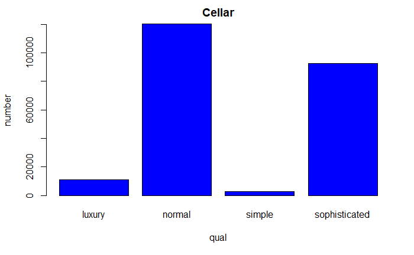

```r
plot(as.factor(temp), col="blue", xlab="qual", ylab="number", main="Cellar")
```

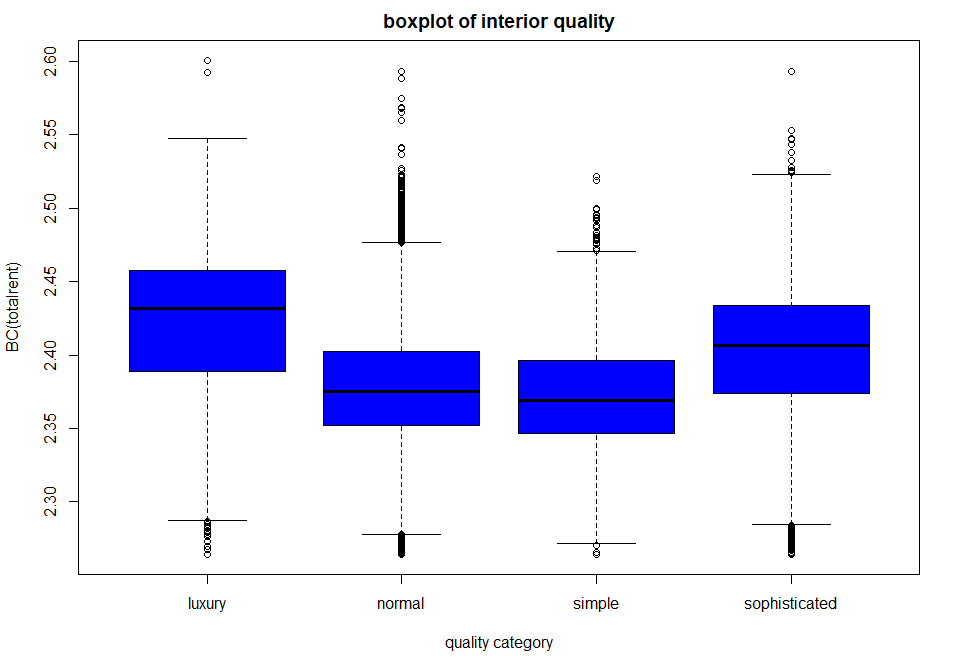

```r
boxplot(data_raw$totalRent~temp, col="blue", stroke="red",
        main="boxplot of interior quality", xlab = "quality category", ylab="BC(totalrent)")
```

so the tendency is that luxury and sophisticated flats are more expensive then normal or simple ones. This reflects the intuitive guess.

```r
temp
```

[output not shown]

### street

```r
sum(temp=='no_information')
```

[output not shown]

So this is basically simmilar to regio3 where we narrow down the geo location to the street level. We will abandon this feature for same reasons.

```r
data_raw = subset(data_raw, select=-c(street))
```

### streetplain

```r
temp = data_raw$streetPlain
head(temp, 10)
```

```
 [1] NA                       "Robert-Gernhardt-Platz" NA                       NA                       "Aurelienstr."           NA                       "BÃ¶melburgweg"
 [8] NA                       NA                       "Helene-Weigel-StraÃŸe"
```

Same Information same reasoning.

```r
data_raw = subset(data_raw, select=-c(streetPlain))
```

### lift

```r
sum(is.na(temp))
```

[output not shown]

This is a categorical feature telling us about the existence of an elevator.

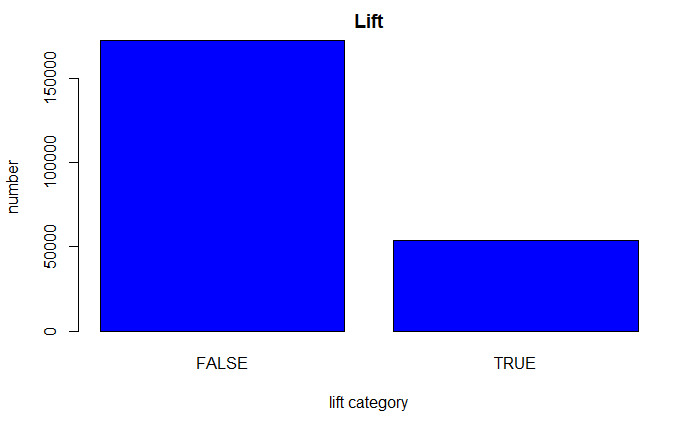

```r
plot(as.factor(temp), col="blue", xlab="lift category", ylab="number", main="Lift")
```

So most flats actually do not have an elevator.

We follow our usual encoding strategy.

```r
temp = ifelse(temp == FALSE, 0, 1)
```

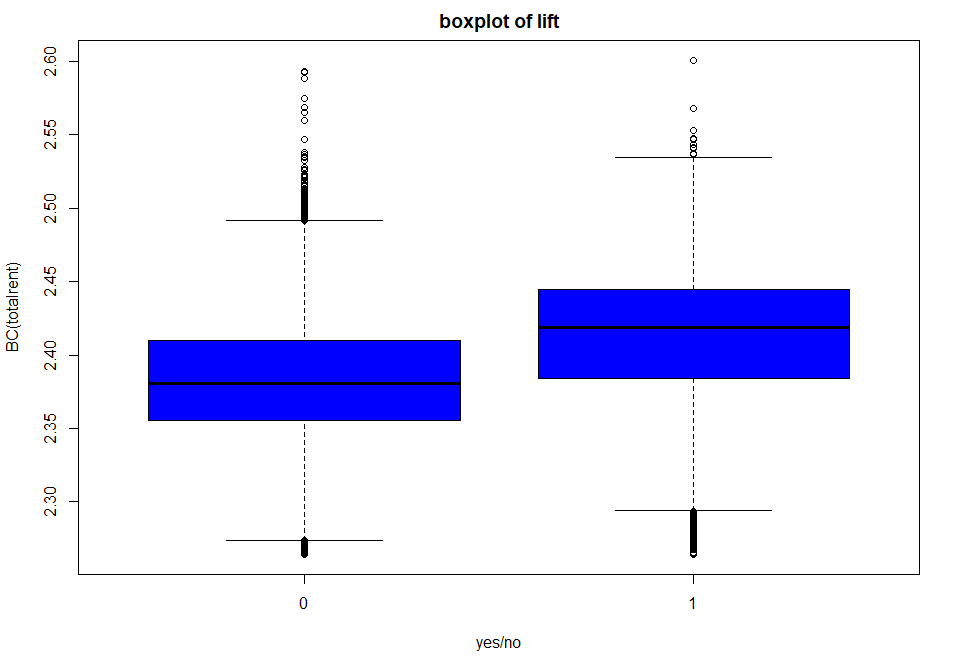

```r
boxplot(data_raw$totalRent~temp, col="blue", stroke="red",
        main="boxplot of lift", xlab = "yes/no", ylab="BC(totalrent)")
```

Flats with a lift do indeed cost more!

```r
data_raw$lift = temp
```

### typeofflat

```r
temp = data_raw$typeOfFlat
head(temp, 10)
```

```
 [1] "roof_storey"  "apartment"    "ground_floor" "apartment"    "roof_storey"  "apartment"    "apartment"    "roof_storey"  "other"        "apartment"
```

This tells us about the kind of flat we are dealing with.

```r
unique(temp)
```

```
 [1] "roof_storey"         "apartment"           "ground_floor"        "other"               NA                    "raised_ground_floor" "terraced_flat"       "half_basement"
 [9] "maisonette"          "penthouse"           "loft"
```

```r
sum(is.na(temp))
```

```
[1] 30292
```

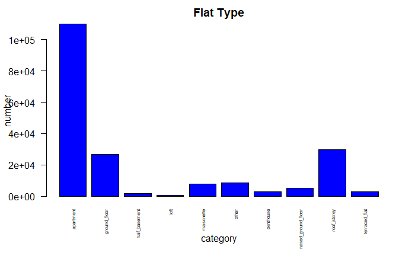

```r
plot(as.factor(temp), col="blue", xlab="category", ylab="number", main="Flat Type", las=2, cex.names=0.5)
```

So most flats are apartments. We do have some options for imputating here. * add all to the apparments category * add all to the others category * remove them from the data set * draw again from the distribution

I will go with the distribution method again.